# The Kaldor Growth Facts

### Loading packages etc.

We first clear the workspace using `rm(list = ls())`and then include all packages we need. If a package is missing in your R distribution (which is quite likely initially), just use `install.packages("package_name")` with the respective package name to install it on your system. If you execute the code in the file `install_packages.R`, then all necessary packages will be installed into your R distribution. If the variable `export_graphs` is set to `TRUE`, then the graphs will be exported as pdf-files. In addition, we define a set of colors here to make graphs look more beautiful.

```r
rm(list = ls())
library(reshape2)
library(base)
library(ggplot2)
library(grid)
library(scales)
library(stringr)
library(tidyverse)
library(pwt10)

# should graphs be exported to pdf
export_pdf <- FALSE

# define some colors
mygreen <- "#00BA38"
myblue  <- "#619CFF"
myred   <- "#F8766D"
```

### Loading the Penn World Tables and extracting US data

We again use the Penn World Tables in `pwt10.0` and extract a sub-dataset that only contains US data.

```r
data("pwt10.01")
pwt_sub <- subset(pwt10.01, isocode=="USA")
```

With these data at hand, we will study the five Kaldor Facts regarding economic growth.

### Fact 1: Output per worker grows at about a constant rate

To establish this fact, we first calculate GDP (or output) per worker in the US economy. In fact, we take the $log$ of GDP, as this allows us to study the growth properties of a variable (see our discussion in the lecture). We then regress output per worker on a constant as well as a linear time trend.

```r
# calculate log-Output-per-Worker
pwt_sub$output_per_worker <- log(pwt_sub$rgdpe/pwt_sub$emp)

# run a linear regression
reg <- lm(output_per_worker ~ year, pwt_sub)
summary(reg)
```

```
##
## Call:
## lm(formula = output_per_worker ~ year, data = pwt_sub)
##
## Residuals:
##      Min       1Q   Median       3Q      Max
## -0.08511 -0.02928 -0.01235  0.02778  0.08561
##
## Coefficients:
##               Estimate Std. Error t value Pr(>|t|)
## (Intercept) -22.309186   0.480306  -46.45   <2e-16 ***
## year          0.016905   0.000242   69.85   <2e-16 ***
## ---
## Signif. codes:  0 '***' 0.001 '**' 0.01 '*' 0.05 '.' 0.1 ' ' 1
##
## Residual standard error: 0.04091 on 68 degrees of freedom
## Multiple R-squared:  0.9863, Adjusted R-squared:  0.9861
## F-statistic:  4879 on 1 and 68 DF,  p-value: < 2.2e-16
```

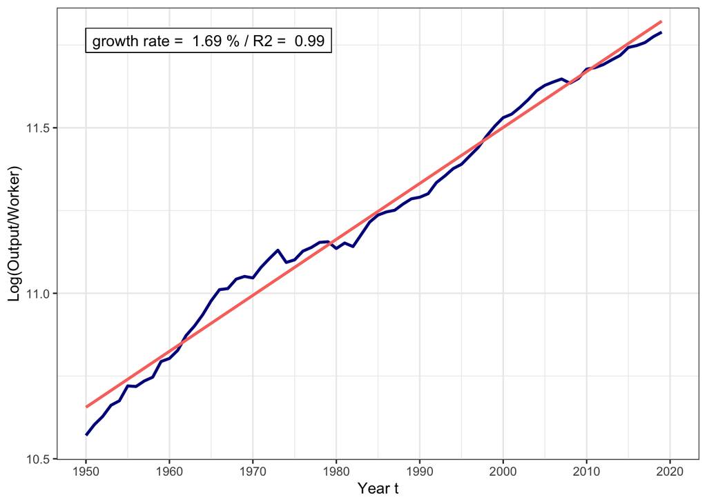

```r
# for graph dimensions and annotation
xrng <- range(pwt_sub$year)
yrng <- range(pwt_sub$output_per_worker)
ymin <- (yrng[1]+yrng[2])/2 - 0.018*(xrng[2]-xrng[1])/2
ymax <- (yrng[1]+yrng[2])/2 + 0.018*(xrng[2]-xrng[1])/2
lab  <- paste("growth rate = ", format(round(reg$coefficients[2]*100, 2), nsmall=2), "% / R2 = ", format(round(summary(reg)$r.squared, 2), nsmall=2))

# generate plot
myplot <- ggplot(data = pwt_sub) +
  geom_line(aes(x=year, y=output_per_worker), color="darkblue", linewidth=1) +
  geom_smooth(aes(x=year, y=output_per_worker), method="lm", formula="y ~ x", se=FALSE, color=myred) +
  geom_label(aes(x = xrng[1], y = ymax, label = lab),
            hjust = 0, vjust = 1, label.r = unit(0, "lines"), label.padding = unit(0.35, "lines")) +
  coord_cartesian(xlim=c(1950, 2020), ylim=c(ymin, ymax)) +
  scale_x_continuous(breaks=seq(1950, 2020, 10)) +
  labs(x = "Year t",
       y = "Log(Output/Worker)") +
  theme_bw()

# print the plot
print(myplot)
```

Note that the above graph is designed such that the y-axis range covers as span of $0.018 \cdot (2019 - 1950)$ log-points (1.8 percent growth per year) and that the presented series is centered on the y-axis. Our 1.7 percent GDP per worker growth series therefore perfectly fits this graph.

### Fact 2: Capital per worker grows at about a constant rate

We can again calculate capital per worker and run a linear regression.

```r
# calculate capital per worker
pwt_sub$capital_per_worker <- log(pwt_sub$rnna/pwt_sub$emp)

# run a linear regression
reg <- lm(capital_per_worker ~ year, pwt_sub)
summary(reg)
```

```
##
## Call:
## lm(formula = capital_per_worker ~ year, data = pwt_sub)
##
## Residuals:
##       Min        1Q    Median        3Q       Max
## -0.096496 -0.018942  0.006438  0.029697  0.069123
##
## Coefficients:
##               Estimate Std. Error t value Pr(>|t|)
## (Intercept) -1.482e+01  4.573e-01  -32.40   <2e-16 ***
## year         1.381e-02  2.304e-04   59.93   <2e-16 ***
## ---
## Signif. codes:  0 '***' 0.001 '**' 0.01 '*' 0.05 '.' 0.1 ' ' 1
##
## Residual standard error: 0.03895 on 68 degrees of freedom
## Multiple R-squared:  0.9814, Adjusted R-squared:  0.9811
## F-statistic:  3592 on 1 and 68 DF,  p-value: < 2.2e-16
```

Capital per worker grows less than GDP per worker (only about 1.38 percent per year), but the $R^2$ value is very high as well. The following graph visualizes this.

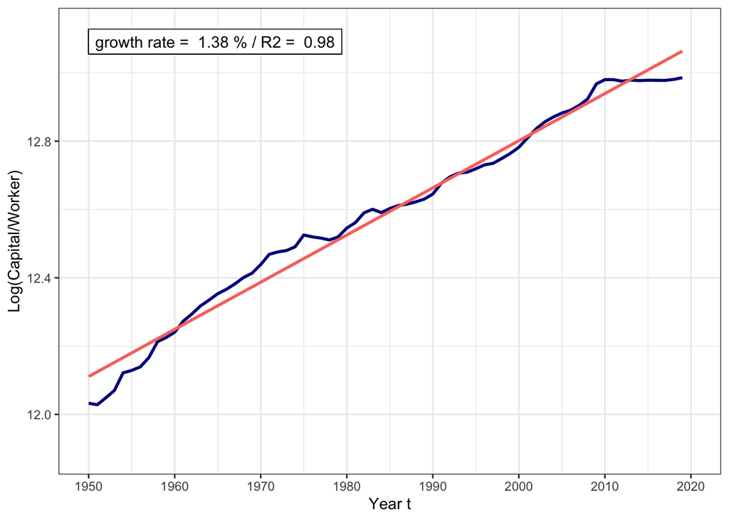

```r
# for graph dimensions and annotation
xrng <- range(pwt_sub$year)
yrng <- range(pwt_sub$capital_per_worker)
ymin <- (yrng[1]+yrng[2])/2 - 0.018*(xrng[2]-xrng[1])/2
ymax <- (yrng[1]+yrng[2])/2 + 0.018*(xrng[2]-xrng[1])/2
lab  <- paste("growth rate = ", format(round(reg$coefficients[2]*100, 2), nsmall=2), "% / R2 = ", format(round(summary(reg)$r.squared, 2), nsmall=2))

# generate plot
myplot <- ggplot(data = pwt_sub) +
  geom_line(aes(x=year, y=capital_per_worker), color="darkblue", linewidth=1) +
  geom_smooth(aes(x=year, y=capital_per_worker), method="lm", formula="y ~ x", se=FALSE, color=myred) +
  geom_label(aes(x = xrng[1], y = ymax, label = lab),
             hjust = 0, vjust = 1, label.r = unit(0, "lines"), label.padding = unit(0.35, "lines")) +
  coord_cartesian(xlim=c(1950, 2020), ylim=c(ymin, ymax)) +
  scale_x_continuous(breaks=seq(1950, 2020, 10)) +
  labs(x = "Year t",
       y = "Log(Capital/Worker)") +
  theme_bw()

# print the plot
print(myplot)
```

### Fact 3: The gross rate of return on capital is roughly constant over time

The gross return on capital is defined as the amount of capital compensation divided by the capital stock. It hence includes both the net return on capital (in the PWT named `irr`) as well as the capital decpreciation rate `delta`. As we can see in the graph below, the gross return on capital is roughly constant over time and ranges at around 11 to 12 percent.

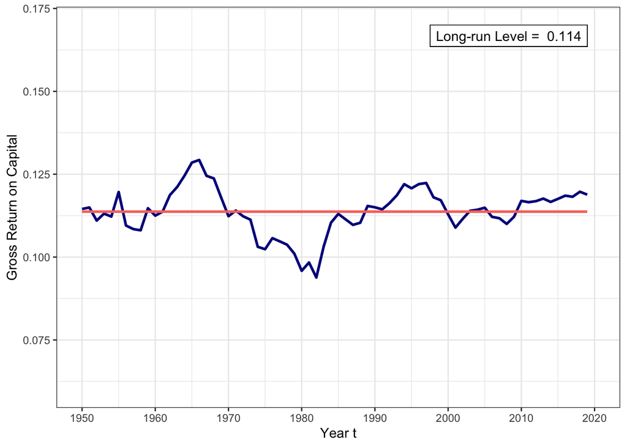

```r
# calculate gross rate of return on capital
pwt_sub$gross_return <- pwt_sub$irr + pwt_sub$delta

# for annotating
xrng <- range(pwt_sub$year)
yrng <- range(pwt_sub$gross_return)
ymin <- 0.06
ymax <- 0.17
lab  <- paste("Long-run Level = ", format(round(mean(pwt_sub$gross_return), 3), nsmall=3))

myplot <- ggplot(data = pwt_sub) +
  geom_line(aes(x=year, y=gross_return), color="darkblue", linewidth=1) +
  geom_smooth(aes(x=year, y=gross_return), method="lm", formula="y ~ 1", se=FALSE, color=myred) +
  geom_label(aes(x = xrng[2], y = ymax, label = lab),
             hjust = 1, vjust = 1, label.r = unit(0, "lines"), label.padding = unit(0.35, "lines")) +
  coord_cartesian(xlim=c(1950, 2020), ylim=c(ymin, ymax)) +
  scale_x_continuous(breaks=seq(1950, 2020, 10)) +
  labs(x = "Year t",
       y = "Gross Return on Capital") +
  theme_bw()

# print the plot
print(myplot)
```

### Fact 4: The capital-to-output ratio is roughly constant over a long period

We can calculate the capital-to-output ratio (again in logs) and study its properties.

```r
# calculate capital-to-output ratio
pwt_sub$capital_to_output <- log(pwt_sub$rnna/pwt_sub$rgdpna)

# run a linear regression
reg <- lm(capital_to_output ~ year, pwt_sub)
summary(reg)
```

```
##
## Call:
## lm(formula = capital_to_output ~ year, data = pwt_sub)
##
## Residuals:
##       Min        1Q    Median        3Q       Max
## -0.043863 -0.023170  0.001303  0.015510  0.075039
##
## Coefficients:
##               Estimate Std. Error t value Pr(>|t|)
## (Intercept)  7.2023489  0.2932969   24.56   <2e-16 ***
## year        -0.0029546  0.0001478  -19.99   <2e-16 ***
## ---
## Signif. codes:  0 '***' 0.001 '**' 0.01 '*' 0.05 '.' 0.1 ' ' 1
##
## Residual standard error: 0.02498 on 68 degrees of freedom
## Multiple R-squared:  0.8546, Adjusted R-squared:  0.8525
## F-statistic: 399.7 on 1 and 68 DF,  p-value: < 2.2e-16
```

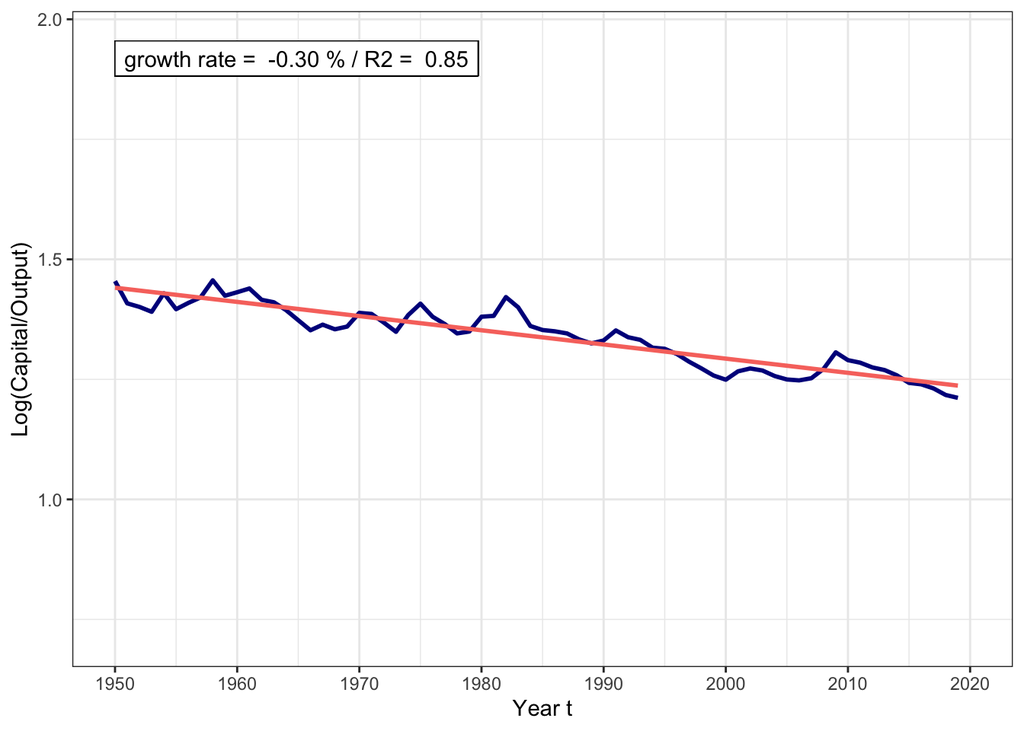

```r
# for graph dimensions
xrng <- range(pwt_sub$year)
yrng <- range(pwt_sub$capital_to_output)
ymin <- (yrng[1]+yrng[2])/2 - 0.018*(xrng[2]-xrng[1])/2
ymax <- (yrng[1]+yrng[2])/2 + 0.018*(xrng[2]-xrng[1])/2
lab  <- paste("growth rate = ", format(round(reg$coefficients[2]*100, 2), nsmall=2), "% / R2 = ", format(round(summary(reg)$r.squared, 2), nsmall=2))

# generate plot
myplot <- ggplot(data = pwt_sub) +
  geom_line(aes(x=year, y=capital_to_output), color="darkblue", linewidth=1) +
  geom_smooth(aes(x=year, y=capital_to_output), method="lm", formula="y ~ x", se=FALSE, color=myred) +
  geom_label(aes(x = xrng[1], y = ymax, label = lab),
             hjust = 0, vjust = 1, label.r = unit(0, "lines"), label.padding = unit(0.35, "lines")) +
  coord_cartesian(xlim=c(1950, 2020), ylim=c(ymin, ymax)) +
  scale_x_continuous(breaks=seq(1950, 2020, 10)) +
  labs(x = "Year t",
       y = "Log(Capital/Output)") +
  theme_bw()

# print the plot
print(myplot)
```

### Fact 5: The share of labor compensation in GDP is roughly constant over time

Finally, we want to take a look at the share of labor compensation in GDP. Labor compensation includes all wages, salaries and benefits paid by firms and the government. Again, the labor share is roughly constant over time. It declined somewhat starting in the 1980s and also from the beginning 2000s, a phenomenon rightly summarized under **the decline of the labor share** in the literature. But for our purposes, we can safely assume this share to be roughly constant over a longer period of time.

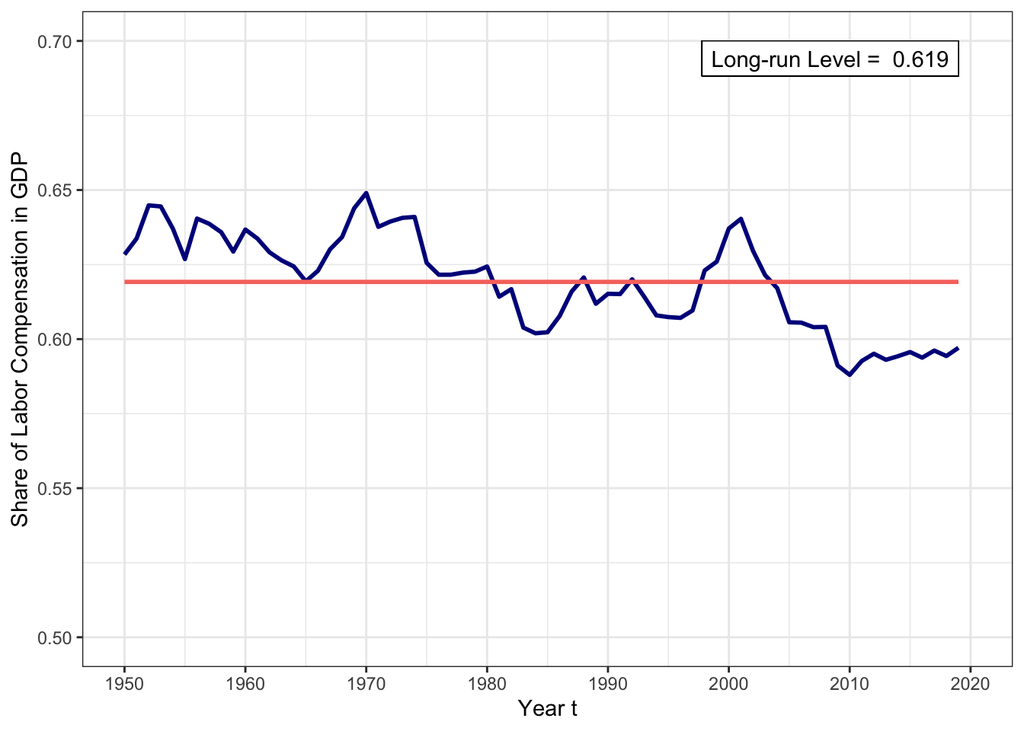

```r
# for annotating
xrng <- range(pwt_sub$year)
yrng <- range(pwt_sub$labsh)
ymin <- 0.5
ymax <- 0.7
lab  <- paste("Long-run Level = ", format(round(mean(pwt_sub$labsh), 3), nsmall=3))

myplot <- ggplot(data = pwt_sub) +
  geom_line(aes(x=year, y=labsh), color="darkblue", linewidth=1) +
  geom_smooth(aes(x=year, y=labsh), method="lm", formula="y ~ 1", se=FALSE, color=myred) +
  geom_label(aes(x = xrng[2], y = ymax, label = lab),
             hjust = 1, vjust = 1, label.r = unit(0, "lines"), label.padding = unit(0.35, "lines")) +
  coord_cartesian(xlim=c(1950, 2020), ylim=c(ymin, ymax)) +
  scale_x_continuous(breaks=seq(1950, 2020, 10)) +
  labs(x = "Year t",
       y = "Share of Labor Compensation in GDP") +
  theme_bw()

# print the plot
print(myplot)
```